# Using the Data Science Pipeline to Save Money Smarter

# Machine Learning and Hypothesis Testing

The next step is to create models from the data that allow us to reliably calculate how much money you would lose of gain in the future. I'm going to use linear regression to find the slopes of the models.

Linear regression is perhaps the most straightforward tactic for machine learning, in which the computer generates a line of best fit, minimizing the total distance (residual) for the true data. It gives us an estimated slope and bias (y-intercept). This may not be helpful if the data does not have a linear relationship (as this is assumed). We would expect the data to be more exponential than linear, but the difference between exponential and linear in this short of a time period is negligible. If we wanted to better fit something that was exponential, we could use polyfit or interaction terms, but this won't be necessary.

We will use the linear model from SKLearn - SKLearn docs: https://scikit-learn.org/stable/user_guide.html

We are not necessarily concerned with the biases in this specific use case, as they are not really important to make future predictions. We keep them anyway so we can check the fits later on.

```python
from sklearn.linear_model import LinearRegression

df_train = df_clean_2009.copy()

df_train["month_delta"] = df_train["date"].map(lambda x: get_month_delta(pd.to_datetime("5/1/2009"), x) + 1)

x_vals = np.array(df_train["month_delta"].to_list()).reshape(-1, 1)
results = {}

# Linear regression for the accounts
for col in cols:
    reg = LinearRegression()
    reg = reg.fit(x_vals, np.array(df_train[col + " interest (adjusted)"].to_list()).reshape(-1, 1))
    results[col] = (reg.coef_[0][0], reg.intercept_[0])

# Linear regression for gold investment
df_train_gold = (df_train.loc[df_train["gold interest (adjusted)"] > 0]).copy()

reg = LinearRegression()
reg = reg.fit(np.array(df_train_gold["month_delta"].to_list()).reshape(-1, 1), np.array(df_train_gold["gold interest (adjusted)"].to_list()).reshape(-1, 1))
results["gold"] = (reg.coef_[0][0], reg.intercept_[0])

results
```

```
{'savings': (-0.0006615069968276128, 1.0083307653031142),
 'checking': (-0.0008653214119036393, 1.0002032346371315),
 'money market': (-0.00037518654810559667, 1.021729359548015),
 '1 month CD': (-0.000668030720890915, 1.0079613393379816),
 '3 month CD': (-0.0003526810067646925, 1.0265295883018988),
 '6 month CD': (0.0002539673516912097, 1.043067912318345),
 '12 month CD': (0.0013998010825920313, 1.0592085023133733),
 '24 month CD': (0.0034300683446121237, 1.0848252913561671),
 '36 month CD': (0.005687232564269877, 1.0929201304147524),
 '48 month CD': (0.008037294923394334, 1.0900064274733425),
 '60 month CD': (0.012253749849245179, 1.0514582667245298),
 'gold': (-0.0013110124771311136, 1.3997662501745414)}
```

We have this map of slopes and biases.

Now to graph the models against the actual data to see how well they fit

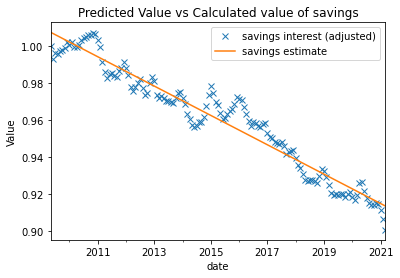

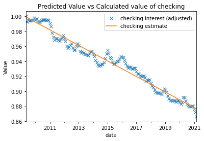

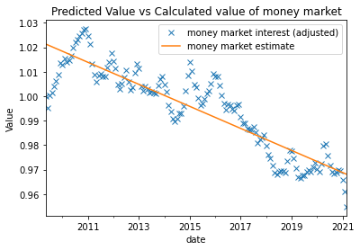

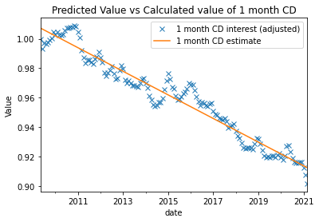

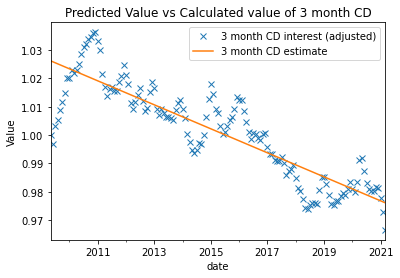

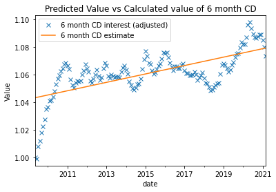

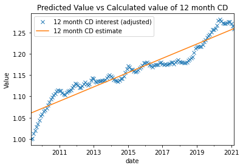

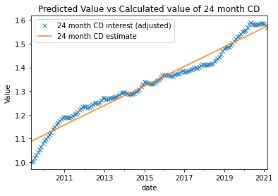

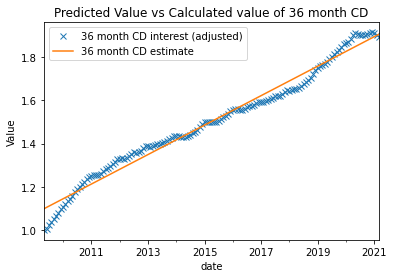

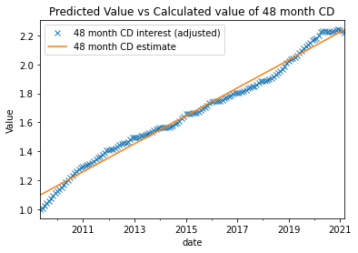

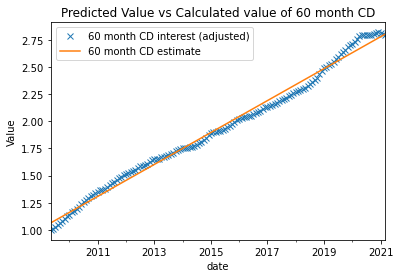

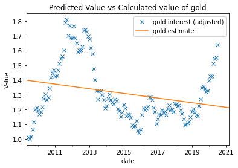

```python
# run through and graph all of the models
for col in cols + ["gold"]:
    df_train[col + " estimate"] = df_train["month_delta"].map(lambda x : results[col][0] * x + results[col][1])
    df_train.plot(x="date", y=[col+" interest (adjusted)", col+" estimate"], style=["x"], title="Predicted Value vs Calculated value of " + col, ylabel="Value")
```

All but the last regression seem to fit well.

We saw already that gold did not look very linear in the 10-year span, so it is unsurprising that the linear regression is confused.

Let's try again using gold data from a larger range of values - this should help reduce the effect of the large dip in the center of the 10-year span.

```
(0.0010105559443416498, 0.9697902860047505)
```

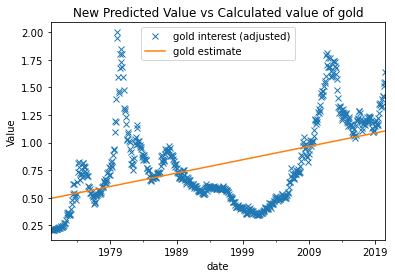

```python
# getting all rows where gold value is > 0 and after 1970
new_gold_train = ((df_clean.loc[df_clean["date"] >= pd.to_datetime("1/1/1970")]).loc[df_clean["gold_price"] > 0]).copy()

# repeating a lot of our calculations again with this new range
# start in the same place as before so everything matches up
starting_row = new_gold_train.loc[new_gold_train["date"] == pd.to_datetime("5/1/2009")]
start_CPI = starting_row["CPI"].to_list()[0]
start_gold_price = starting_row["gold_price"].to_list()[0]

new_gold_train["month_delta"] = new_gold_train["date"].map(lambda x: get_month_delta(pd.to_datetime("5/1/2009"), x) + 1)
new_gold_train["gold interest"] = new_gold_train["gold_price"].map(lambda x: gold_investment_USD(1, start_gold_price, x))
new_gold_train["gold interest (adjusted)"] = new_gold_train.apply(lambda x: relative_value(float(start_CPI), float(x["gold interest"]), float(x["CPI"])), axis=1)

reg = LinearRegression()
reg = reg.fit(np.array(new_gold_train["month_delta"].to_list()).reshape(-1, 1), np.array(new_gold_train["gold interest (adjusted)"].to_list()).reshape(-1, 1))
new_result = (reg.coef_[0][0], reg.intercept_[0])

print(new_result)

new_gold_train["gold estimate"] = new_gold_train["month_delta"].map(lambda x : new_result[0] * x + new_result[1])
new_gold_train.plot(x="date", y=["gold interest (adjusted)", "gold estimate"], style=["x"], title="New Predicted Value vs Calculated value of " + col, ylabel="Value")
```

This model looks more slightly more reasonable.

We can test this using hypothesis testing.

Hypothesis testing is determining if values are close enough statistically to other values for them to be considered "close enough" to being the same. The value that determines the "closeness" is called the P-value. In most applications, the P-value minimum would be 0.05, so we will use that.

P Value: 0.05 - i.e. 5%

We also need values to test. We will use a method that looks similar to k-fold cross-validation, in which we split the data into a training and testing set, fit the values, then perform a t-test to get the P values. In this case k=8, but k can be any reasonable number that denotes the number of groups the data is split into. We also need to divide by variance because the variances of the smaller and larger sets are quite different.

This is somewhat different from a real k-fold cross validation because it is really used on the same dataset for comparing multiple modeling algorithms. In this circumstance, I am using it to test different subsets of the dataset with the same modeling algorithm. Focus more on the concept of hypothesis testing rather than the generation of the normalized residuals because my process is unorthodox.

```python
from sklearn.model_selection import train_test_split

# Splits the data into 8 random, independent subsets for 8-fold cross-validation
# Edited code from project 3 EC
def ksplit(X, y):
    x_split = []
    y_split = []
    X_temp = X
    y_temp = y

    remaining = 100
    while ((12.5/remaining) != 1):
        nd = remaining * (12.5/remaining)
        X_train, X_test, y_train, y_test = train_test_split(X_temp, y_temp, test_size= (10/remaining))
        x_split.append(X_test)
        y_split.append(y_test)
        X_temp = X_train
        y_temp = y_train
        remaining = (remaining-nd)
    x_split.append(X_train)
    y_split.append(y_train)
    return (x_split, y_split)

def validation(x_split, y_split):
    average_residuals = []

    for index, subset in enumerate(x_split):
        # creating the train and test sets
        temp_x = np.array(x_split.copy(), dtype=object)
        temp_y = np.array(y_split.copy(), dtype=object)

        # taking out the test group
        test_set_x = subset
        temp_x = np.delete(temp_x, index)
        test_set_y = temp_y[index]
        temp_y = np.delete(temp_y, index)

        # re-combining the other 7 groups
        train_set_x = np.array([])
        train_set_y = np.array([])
        for train_index, train_subset in enumerate(temp_x):
            if (not train_set_x.any()):
                train_set_x = train_subset
                train_set_y = temp_y[train_index]
            else:
                 train_set_x = np.concatenate((train_set_x,  train_subset))
                 train_set_y = np.concatenate((train_set_y,  temp_y[train_index]))


        # Testing
        reg = LinearRegression()
        reg.fit(train_set_x, train_set_y)

        residual_num = 0
        residual_sum = 0
        for idx, val in enumerate(test_set_x):
            residual_sum += abs(test_set_y[idx][0] - reg.predict([val])[0])
            residual_num += 1

        average_residuals.append((residual_sum/residual_num).tolist()[0])
    return average_residuals

# old gold model
gold_X = np.array(df_train_gold["month_delta"].to_list()).reshape(-1, 1)
gold_y = np.array(df_train_gold["gold interest (adjusted)"].to_list()).reshape(-1, 1)
gold_group = ksplit(gold_X, gold_y)
gold_residual = validation(gold_group[0], gold_group[1])

# new gold model
new_gold_X = np.array(new_gold_train["month_delta"].to_list()).reshape(-1, 1)
new_gold_y = np.array(new_gold_train["gold interest (adjusted)"].to_list()).reshape(-1, 1)
new_gold_group = ksplit(new_gold_X, new_gold_y)
new_gold_residual = validation(new_gold_group[0], new_gold_group[1])

# normalize by variance
gold_residual_variance = df_train_gold["gold interest (adjusted)"].var()
new_gold_residual_variance = new_gold_train["gold interest (adjusted)"].var()
gold_residual = [x/gold_residual_variance for x in gold_residual]
new_gold_residual = [x/new_gold_residual_variance for x in new_gold_residual]
```

Now we have the values, so we can use a T-test to test the hypothesis. [SciPy](https://docs.scipy.org/doc/scipy/reference/generated/scipy.stats.ttest_ind.html) adds a function that performs T-tests in one line

```python
import scipy

print("T-test for \"Is the new model better fit than the old one?\" - \n" + str(scipy.stats.ttest_ind(gold_residual, new_gold_residual)) + "\n")
```

```
T-test for "Is the new model better fit than the old one?" -
Ttest_indResult(statistic=8.236903784486579, pvalue=9.734288291659962e-07)
```

The P-value is significantly smaller than 0.05, indicating that the two are significantly different. The associated statistic suggests that the old model has a higher adjusted residual than the new model (because it is positive). A higher residual indicates a worse fit.

We can reject our null hypothesis and accept our alternate hypothesis. For this example.

# Conclusion - Insight

The ultimate goal of this project was to get the slopes of the linear regressions, which help us answer the questions we asked in the beginning. Perhaps the most important part of data science is communicating the insights we learned from the data.

Let's remind ourselves of the central questions of the project:

"Is money that sits in savings accounts constantly losing buying power? Furthermore, what is the minimum risk required to prevent yourself from losing money over time? Certificate of deposit? Gold?"

Let's look at the slopes we found, including the new slope for gold. This is where we drop bias because we want to generalize to all principle investments.

```python
for key in results.keys():
    if (key != "gold"):
        rounded = round(results[key][0]* 100, 4)
        print(key + ": " + str(rounded)+ "% per month   " + str(round(rounded*12, 6)) + "% per year")

rounded = round(new_result[0]* 100, 4)
print("gold (new): " + str(rounded) + "% per month   " + str(round(rounded * 12, 6)) + "% per year")
```

```
savings: -0.0662% per month   -0.7944% per year
checking: -0.0865% per month   -1.038% per year
money market: -0.0375% per month   -0.45% per year
1 month CD: -0.0668% per month   -0.8016% per year
3 month CD: -0.0353% per month   -0.4236% per year
6 month CD: 0.0254% per month   0.3048% per year
12 month CD: 0.14% per month   1.68% per year
24 month CD: 0.343% per month   4.116% per year
36 month CD: 0.5687% per month   6.8244% per year
48 month CD: 0.8037% per month   9.6444% per year
60 month CD: 1.2254% per month   14.7048% per year
gold (new): 0.1011% per month   1.2132% per year
```

These numbers show the estimated percentage of the principal value you will earn back over 1 month and 1 year. NOTE: This will not reflect the USD AMOUNT of money in the account! This is a measure of buying power!

For example, in a 12 month CD, you will be able to buy on average 1.68% more potatoes than you could when you started. In that year span, the price of potatoes has changed, but so has the money in your account. This is a way to keep value currency agnostic.

We can finally answer our questions. (With the stipulation that we are basing our projections on the last 10 years of data and using the perfectly average interest rates; data science always comes with assumptions)

"Is money that sits in savings accounts constantly losing buying power?" -

Yes! Money is losing buying power over time regardless of interest (assuming average interest rate). This is true of average checking, savings, and money market accounts. It is possible to find better-than-average rates for these accounts, so it is possible to outperform the model if we are lucky.

"What is the minimum risk required to prevent your account from losing money over time? Certificate of deposit? Gold?" -

The minimum risk would be giving up our money to a bank for 6 months. The minimum time appears to be an average 6 month CD, which makes next to nothing, but is able to preserve value. Any longer CD has the potential to earn increasingly higher values in the same time period, but lock in the money for longer.

In conclusion, we must decide beforehand how quickly we need to use our money. If the money will be unused for decades, it is best to get a 60 month CD, but if we need absolute flexibility, gold may be a better (albeit more risky) option.

I hope that this walkthrough/project has taught you some ways data scientists leverage the data science pipeline to generate insights. I would appreciate your feedback and comments. I can be contancted at:

Jack T. Wilcom  
Email: jtwilcom@wilcomweb.net  
Twitter: @FlyingPeng11

Data sources:

https://data.bls.gov/cgi-bin/surveymost?cu

https://www.fdic.gov/regulations/resources/rates/historical/archive.xlsx

https://pkgstore.datahub.io/core/gold-prices/monthly_json/data/3b036045b9090ddacfaacb2deb5f19de/monthly_json.json